# PartialFKR User Manual

### 11.4 Export as SuperCollider

Exports a self-contained **SuperCollider `.scd`** file. Open it in the SuperCollider IDE and evaluate the outer block (⌘Return on macOS) to boot the server, load buffers, and play back the resynthesis.

The script uses `Env.asSignal` to discretize each partial’s breakpoint envelope into a server buffer at 5 ms resolution, then schedules one `Synth` per partial at its analysis onset time.

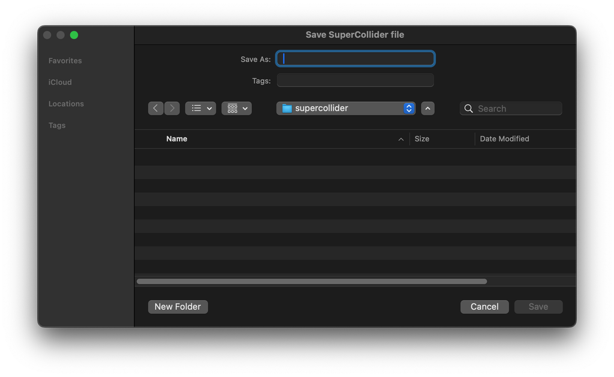

S-48 — SuperCollider export dialog

### 11.5 Export as SDIF

Exports partials in the **SDIF** (Sound Description Interchange Format), compatible with Loris, SPEAR, and other analysis tools.

A dialog lets you choose the frame type: - **1TRC** — standard sinusoidal tracks (compatible with most tools) - **RBEP** — Loris bandwidth-enhanced partial format (preserves noise residual data)

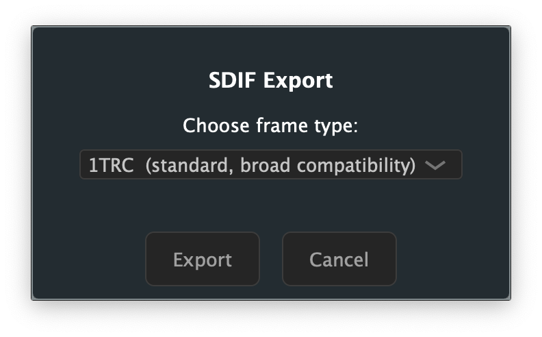

S-46 — SDIF export dialog showing frame type options

### 11.6 Export as JSON

Exports partials as a JSON file, useful for data interchange with custom tools or scripts.

Each partial is represented as an object with metadata (id, start time, duration, color) and an array of breakpoints (time, frequency, amplitude, bandwidth, phase).

### 11.7 Export Audio

Renders the current resynthesis to an audio file — **you hear exactly what you export**. Muted partials are excluded; if any partial is soloed, only soloed partials are rendered.

Invoke via **File → Export → Export Audio…**

A dialog opens with a horizontal tab strip for choosing the output format. The default tab is **AIFF**.

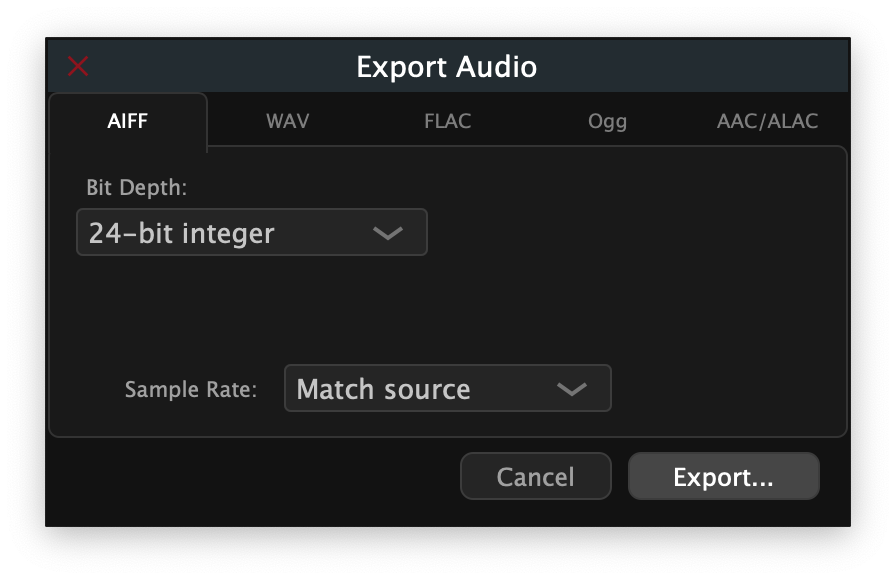

S-49 — Export Audio dialog, AIFF tab (default)

#### Format tabs

| Tab | Format | Notes |
| --- | --- | --- |
| AIFF | Audio Interchange File Format | Bit depths: 16-bit int / 24-bit int / 32-bit float |
| WAV | Waveform Audio | Bit depths: 16-bit int / 24-bit int / 32-bit float |
| FLAC | Free Lossless Audio Codec | Bit depths: 16-bit / 24-bit; Compression 1 (fastest) – 8 (smallest) |
| Ogg | Ogg Vorbis (lossy) | Quality slider 0.0 (lowest) – 1.0 (highest); default 0.5 |
| AAC/ALAC | Apple lossy / lossless | **macOS only.** Toggle between AAC (128 – 320 kbps) and ALAC (16 / 24-bit lossless) |

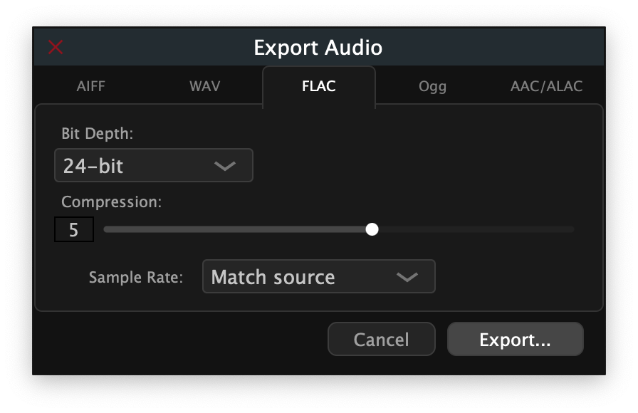

S-50 — FLAC tab showing bit depth and compression options

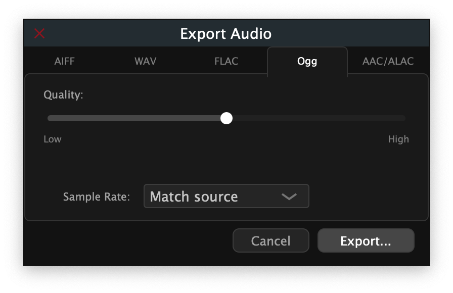

S-52 — Ogg tab showing quality slider

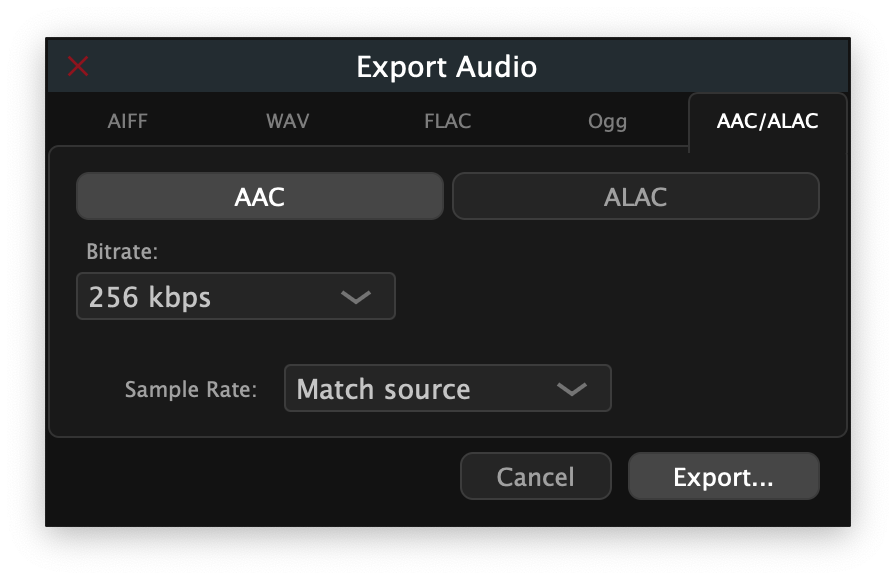

S-51 — AAC/ALAC tab (macOS only) showing codec toggle and bitrate options

> **Note:** The AAC/ALAC tab appears only on macOS. On other platforms, FLAC (24-bit, compression 5) is the recommended lossless format.

#### Sample rate

A **Sample Rate** selector below the option panels offers: - **Match source** — uses the sample rate of the analyzed audio file (recommended) - 44 100 Hz / 48 000 Hz / 96 000 Hz — override if your target system requires a specific rate

#### Exporting

Click **Export…** to open a file save dialog. The file extension filter matches the selected format automatically. The render runs immediately after you confirm the file path; progress completes silently for typical analysis lengths (under 30 s). On completion the file is ready to use in your DAW, notation software, or Csound workflow.

Click **Cancel** to dismiss the dialog without creating a file.

## 12. Keyboard Shortcuts

### File

| Action | Shortcut |
| --- | --- |
| New window | ⌘N |
| Open project | ⌘O |
| Analyze Audio… | — |
| Save | ⌘S |
| Save As | ⌘⇧S |
| Close window | ⌘W |

### Edit

| Action | Shortcut |
| --- | --- |
| Undo | ⌘Z |
| Redo | ⌘⇧Z |
| Cut | ⌘X |
| Copy | ⌘C |
| Paste | ⌘V |
| Delete | Delete or Backspace |
| Select All | ⌘A |
| Deselect All | ⌘⇧A |
| Invert Selection | ⌘⇧I |
| Bridge Partials | ⌘J |
| Crossfade Overlap | ⌘⇧J |
| Stretch / Compress… | T |

### View

| Action | Shortcut |
| --- | --- |
| Zoom In | ⌘= |
| Zoom Out | ⌘− |
| Zoom to Fit | ⌘0 |
| Show/Hide Panel | ⌘⌥S |

### Transport

| Action | Shortcut |
| --- | --- |
| Play / Pause | Space |
| Loop toggle | Transport menu |
| Set In Point to playhead | ⌥I |
| Set Out Point to playhead | ⌥O |
| Set In/Out from Selection | ⌥S |

### Window

| Action | Shortcut |
| --- | --- |
| Minimize window | ⌘M |

### Tools

| Action | Key |
| --- | --- |
| Switch to Select mode | V |
| Switch to Direct Select mode | A |

### Navigation (canvas focused)

| Action | Key |
| --- | --- |
| Pan left / right | ← / → |
| Pan up / down (frequency) | ↑ / ↓ |
| Pan frequency by page | Page Up / Page Down |
| Jump playback to start / end | Home / End (or ⌘← / ⌘→) |
| Zoom frequency in / out | scroll |
| Zoom time in / out | ⌘+scroll or ⌥+scroll |
| Zoom both axes | pinch (trackpad) |
| Pan time | ⇧+scroll |

*PartialFKR is open-source software distributed under the AGPLv3 license.*  
*Source code and issue tracker: github.com/ideocentric/partialfkr*